# SPARX: An Automated, Programmatically Generated Frequency-Scalable Six-Port Receiver in 130-nm CMOS

## Place and Connect Fourth Power Detector (PD4)

PD4 is instantiated with a single Y-axis mirror (`mirror_y()`), then placed by connecting ports:

- Connect `rfin` from `blc_2_ref` port `e2` through the RF interconnect
- Route `vdd` and `vss` to the bottom bondpads
- Route `vout` and `vref` through via-assisted Metal4/Metal3 paths to bottom pads

Like the other detectors, PD4 location is topology-driven and scales with the surrounding layout geometry.

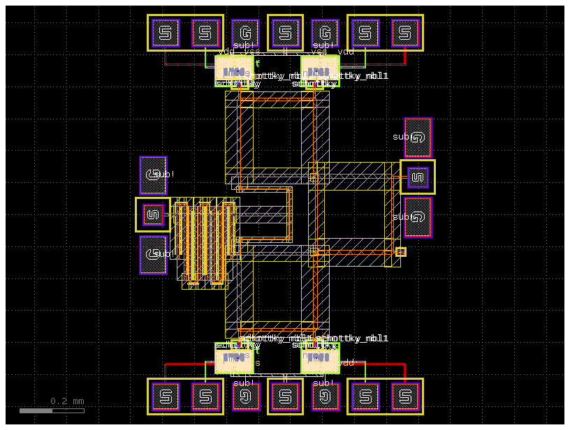

```python
pd4_ref = c.add_ref(pd).mirror_y()
connection_rfin_ref = c.add_ref(connection_rfin)
connection_rfin_ref.connect("e1", blc_2_ref.ports["e2"])
pd4_ref.connect("rfin", connection_rfin_ref.ports["e2"], allow_width_mismatch=True)

# vdd connection of pd4 to probe bottom
route_pd4_vdd = gf.routing.route_bundle_electrical(
    component=c,
    ports1=[pd4_ref.ports["vdd"]],
    ports2=[probe_bottom.ports["e4"]],
    route_width=8,    # adjust for thicker connections
    layer=ihp.tech.LAYER.TopMetal1drawing,
    start_straight_length=10,
    allow_layer_mismatch=True,
    allow_width_mismatch=True,
    auto_taper=False,
    separation=0,
)
# vss connection of pd4 to probe bottom
route_pd4_vss = gf.routing.route_bundle_electrical(
    component=c,
    ports1=[pd4_ref.ports["vss"]],
    ports2=[probe_bottom.ports["e3"]],
    route_width=2,    # adjust for thicker connections
    layer=ihp.tech.LAYER.Metal5drawing,
    start_straight_length=10, # 10 or longer, to avoid routing through itself
    allow_layer_mismatch=True,
    allow_width_mismatch=True,
    auto_taper=False,
    separation=0,
)
# vout connection of pd4 to probe bottom
via_M4_TM1_ref = c.add_ref(via_M4_TM1)
via_M4_TM1_ref.connect("top", probe_bottom.ports["e2"], allow_width_mismatch=True, allow_layer_mismatch=True)
via_M4_TM1_ref.move((0, -via_M4_TM1_ref.ysize/2))
route_pd4_vout = gf.routing.route_bundle_electrical(
    component=c,
    ports1=[pd4_ref.ports["vout"]],
    ports2=[via_M4_TM1_ref.ports["bottom"]],
    route_width=4,    # adjust for thicker connections
    layer=ihp.tech.LAYER.Metal4drawing,
    start_straight_length=10, # 10 or longer, to avoid routing through itself
    allow_layer_mismatch=True,
    allow_width_mismatch=True,
    auto_taper=False,
    separation=0,
)
# vref connection of pd4 to probe bottom
via_M3_TM1_ref = c.add_ref(via_M3_TM1)
via_M3_TM1_ref.connect("top", probe_bottom.ports["e1"], allow_width_mismatch=True, allow_layer_mismatch=True)
via_M3_TM1_ref.move((0, -via_M3_TM1_ref.ysize/2))
route_pd4_vref = gf.routing.route_bundle_electrical(
    component=c,
    ports1=[pd4_ref.ports["vref"]],
    ports2=[via_M3_TM1_ref.ports["bottom"]],
    route_width=4,    # adjust for thicker connections
    layer=ihp.tech.LAYER.Metal3drawing,
    start_straight_length=10, # 10 or longer, to avoid routing through itself
    allow_layer_mismatch=True,
    allow_width_mismatch=True,
    auto_taper=False,
    separation=0,
)

# rfin connection of pd4 to blc
c.plot()
```

## Place Sealring

After the six-port is assembled, it is important to place a sealring around it. The sealring is necessary at the chip edge to stop cracks from spreading during the dicing process. It also works as a metal barrier to block moisture and chemicals from entering the internal layers. This ensures the long-term reliability and prevents corrosion of the semiconductor die.

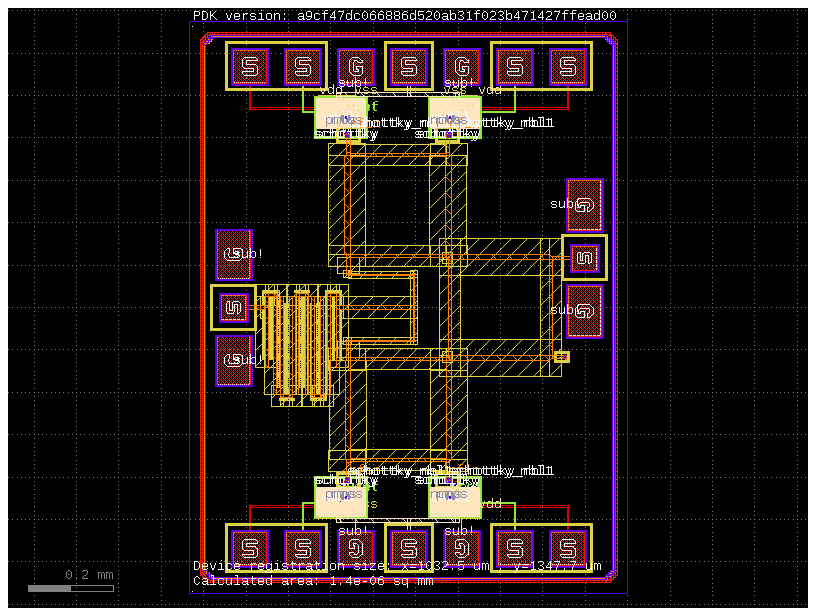

```python
c.add_ref(ihp.cells.sealring(width=c.xsize + 50, height=c.ysize + 50)).center = c.center

c.plot()
```

## Define Metal Fill Patterns

Define helper functions for creating metal fill cells:

These fill cells are used by gdsfactory's `fill()` function to uniformly distribute metal and maintain electrical properties.

```python
@gf.cell
def fill_cell(layer = ihp.tech.LAYER.Metal5slit, size=(3,3)) -> gf.Component:
    c = gf.Component()
    c << gf.c.rectangle(layer=layer, size=size)
    return c

@gf.cell
def fill_gat_active(size=(3,3), active_extension=(0.18,0.18)) -> gf.Component:
    c = gf.Component()
    gat_ref = c.add_ref(gf.c.rectangle(layer=ihp.tech.LAYER.GatPolyfiller, size=size))
    activ_ref = c.add_ref(gf.c.rectangle(layer=ihp.tech.LAYER.Activfiller, size=(size[0] + 2*active_extension[0], size[1] + 2*active_extension[1])))
    activ_ref.center = gat_ref.center
    return c

@gf.cell
def fill_ground() -> gf.Component:
    c = gf.Component()
    c.add_polygon(layer=ihp.tech.LAYER.Metal5drawing, points=[
        (0,0),
        (1,0),
        (1,1),
        (0,1)
        ])
    return c

@gf.cell
def slit_ground() -> gf.Component:
    c = gf.Component()
    c.add_polygon(layer=ihp.tech.LAYER.Metal5slit, points=[
        (1.1,1.1),
        (4,1.1),
        (4,4.1),
        (1.1,4.1)])
    return c
```

## Fill All Metal Layers

Hierarchical metal fill patterns are applied across all metal layers (GatePoly, Active, Metal1-5, TopMetal1) to:

- maintain CMP (Chemical Mechanical Polishing) uniformity.
- ensure design rule compliance with minimum metal density requirements.
- avoid isolated structures that degrade process performance.
- fill ground planes with slit patterns for optimal RF performance.

Each layer uses appropriate fill cells, spacing, and exclusion zones around signal lines and sensitive structures.

```
2026-04-14 19:49:54.874 | INFO     | kfactory.utils.fill:fill_tiled:278 - done with calculating fill regions for Six-Port-CAC
2026-04-14 19:49:54.939 | INFO     | kfactory.utils.fill:fill_tiled:278 - done with calculating fill regions for Six-Port-CAC
2026-04-14 19:49:55.008 | INFO     | kfactory.utils.fill:fill_tiled:278 - done with calculating fill regions for Six-Port-CAC
2026-04-14 19:49:55.062 | INFO     | kfactory.utils.fill:fill_tiled:278 - done with calculating fill regions for Six-Port-CAC
2026-04-14 19:49:55.115 | INFO     | kfactory.utils.fill:fill_tiled:278 - done with calculating fill regions for Six-Port-CAC
2026-04-14 19:49:55.151 | INFO     | kfactory.utils.fill:fill_tiled:278 - done with calculating fill regions for Six-Port-CAC
2026-04-14 19:49:56.526 | INFO     | kfactory.utils.fill:fill_tiled:278 - done with calculating fill regions for Six-Port-CAC
2026-04-14 19:49:56.596 | INFO     | kfactory.utils.fill:fill_tiled:278 - done with calculating fill regions for Six-Port-CAC
```

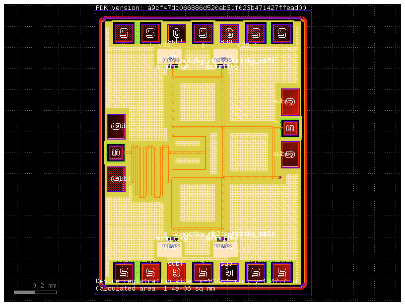

```python
gatpoly_activ_fill_space = 1
c.fill(
    fill_cell=fill_gat_active( size=(3, 3)),
    fill_layers=[(ihp.tech.LAYER.EdgeSealboundary, -50)],
    exclude_layers=[
        (ihp.tech.LAYER.Activdrawing, 1.1),
        (ihp.tech.LAYER.pSDdrawing, 1.1),
        (ihp.tech.LAYER.nSDblock, 1.1),
        (ihp.tech.LAYER.SalBlockdrawing, 1.1),
        (ihp.tech.LAYER.NWelldrawing, 1.1),
        (ihp.tech.LAYER.nBuLaydrawing, 1.1),
        (ihp.tech.LAYER.PWellblock, 1.5),
        (ihp.tech.LAYER.GatPolydrawing, 2),
        (ihp.tech.LAYER.Contdrawing, 1.2),
        (ihp.tech.LAYER.Passivdrawing, 12),
        (ihp.tech.LAYER.GatPolynofill, 1),
        (ihp.tech.LAYER.Activnofill, 1),
        ],
    x_space=gatpoly_activ_fill_space,
    y_space=gatpoly_activ_fill_space,
)
# metal1 fill
metal_fill_space = 1
c.fill(
    fill_cell=fill_cell(layer=ihp.tech.LAYER.Metal1filler),
    fill_layers=[(ihp.tech.LAYER.EdgeSealboundary, -50)],
    exclude_layers=[
        (ihp.tech.LAYER.Metal1drawing, 10),
        (ihp.tech.LAYER.Passivdrawing, 10),
        (ihp.tech.LAYER.Metal1nofill, 1),
        ],
    x_space=metal_fill_space,
    y_space=metal_fill_space,
)
# metal2 fill
c.fill(
    fill_cell=fill_cell(layer=ihp.tech.LAYER.Metal2filler),
    fill_layers=[(ihp.tech.LAYER.EdgeSealboundary, -50)],
    exclude_layers=[
        (ihp.tech.LAYER.Metal2drawing, 10),
        (ihp.tech.LAYER.Passivdrawing, 10),
        (ihp.tech.LAYER.Metal2nofill, 1),
        ],
    x_space=metal_fill_space,
    y_space=metal_fill_space,
)
# metal3 fill
c.fill(
    fill_cell=fill_cell(layer=ihp.tech.LAYER.Metal3filler),
    fill_layers=[(ihp.tech.LAYER.EdgeSealboundary, -50)],
    exclude_layers=[
        (ihp.tech.LAYER.Metal3drawing, 10),
        (ihp.tech.LAYER.Passivdrawing, 10),
        (ihp.tech.LAYER.Metal3nofill, 1),
        ],
    x_space=metal_fill_space,
    y_space=metal_fill_space,
)
# metal4 fill
c.fill(
    fill_cell=fill_cell(layer=ihp.tech.LAYER.Metal4filler),
    fill_layers=[(ihp.tech.LAYER.EdgeSealboundary, -50)],
    exclude_layers=[
        (ihp.tech.LAYER.Metal4drawing, 10),
        (ihp.tech.LAYER.Passivdrawing, 10),
        (ihp.tech.LAYER.Metal4nofill, 1),
        ],
    x_space=metal_fill_space,
    y_space=metal_fill_space,
)
c.fill(fill_cell=fill_ground(),
    fill_layers=[(ihp.tech.LAYER.EdgeSealboundary, -50)],
    exclude_layers=[(ihp.tech.LAYER.Passivdrawing, 0),
    (ihp.tech.LAYER.Metal5nofill, 0)],
    x_space=0,
    y_space=0,
)
c.fill(fill_cell=slit_ground(),
    fill_layers=[(ihp.tech.LAYER.Metal5drawing, -2)],
    exclude_layers=[(ihp.tech.LAYER.TopMetal2drawing, 5), (ihp.tech.LAYER.MIMdrawing, 1), (ihp.tech.LAYER.Metal5slit, 1)],
    x_space=1.1,
    y_space=1.2,
)
c.fill(
        fill_cell=fill_cell(layer=ihp.tech.LAYER.TopMetal1filler, size=(9, 9)),
        fill_layers=[(ihp.tech.LAYER.EdgeSealboundary, -50)],
        exclude_layers=[(ihp.tech.LAYER.TopMetal1drawing, 10), (ihp.tech.LAYER.TopMetal2drawing, 20)],
        x_space=3,
        y_space=3,
    )
c.plot()
```

## Add Logos and Decorative Elements

Import and place decorative logos for the chip:

- **JKU Logo**: Johannes Kepler University branding on TopMetal2
- **D. Kellerer**: Designer name annotation (rotated -90°)
- **IWS Logo**: Institute branding
- **Supervisors**: Acknowledgment text

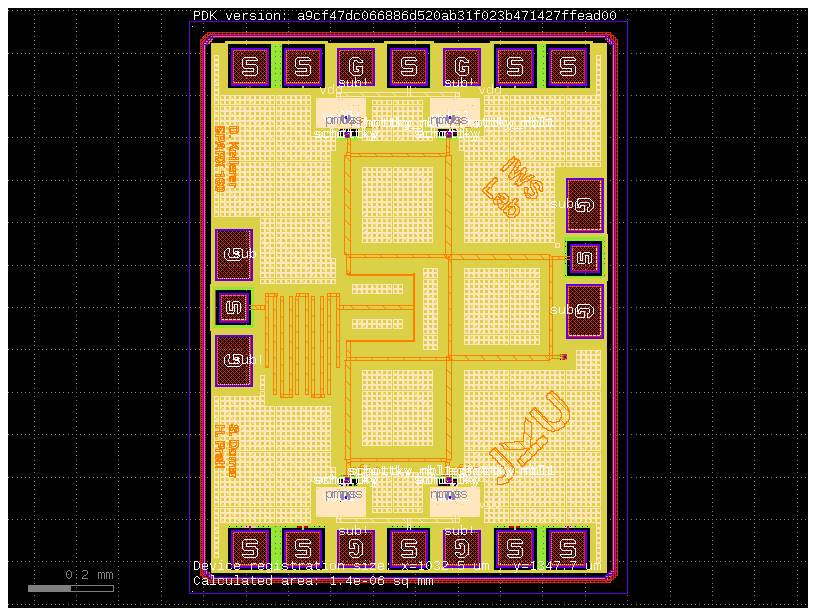

```python
if f == 160e9:

    logo_dir = Path("/tmp/assets")

    # logo_gds_path = logo_dir / "jku_logo_m5.gds"
    logo_gds_path = logo_dir / "jku_logo_m5.gds"
    kellerer_gds_path = logo_dir / "D_Kellerer.gds"
    iws_gds_path = logo_dir / "IWS.gds"
    helper_gds_path = logo_dir / "supervisors.gds"

    tm1_layer = ihp.tech.LAYER.TopMetal2drawing
    tm1_foreground = f"{tm1_layer[0]}/{tm1_layer[1]}"

    logo_jku = c.add_ref(gf.import_gds(str(logo_gds_path), cellname="JKU_LOGO"))
    logo_jku.move((-50,-420))
    kellerer = c.add_ref(gf.import_gds(str(kellerer_gds_path), cellname="Name_D"))
    iws = c.add_ref(gf.import_gds(str(iws_gds_path), cellname="Logo_IWS"))

    kellerer.rotate(-90)
    kellerer.move((-690, 430))

    iws.move((-120,130))

    helper = c.add_ref(gf.import_gds(str(helper_gds_path), cellname="helper")).rotate(-90)
    helper.xmin = kellerer.xmin
    helper.ymax = kellerer.ymin - 550

    c.plot()
```

## Final TopMetal2 Fill and Chip Visualization

The TopMetal2 fill pattern is applied to complete the metal density requirements. Use 9×9µm fill cells with 3µm spacing, excluding the 20µm perimeter around TopMetal2 drawing layers. Plot the final complete chip design to visualize the finished layout with all components, routing, logos, and metal fill in place.

```
2026-04-14 19:49:57.809 | INFO     | kfactory.utils.fill:fill_tiled:278 - done with calculating fill regions for Six-Port-CAC
```

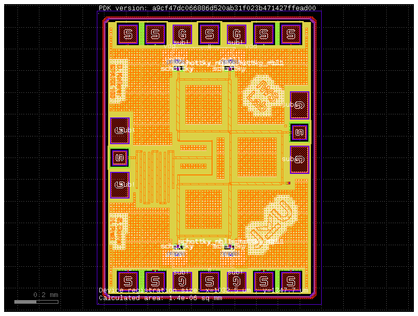

```python
c.fill(
        fill_cell=fill_cell(layer=ihp.tech.LAYER.TopMetal2filler, size=(9, 9)),
        fill_layers=[(ihp.tech.LAYER.EdgeSealboundary, -50)],
        exclude_layers=[(ihp.tech.LAYER.TopMetal2drawing, 20)],
        x_space=3,
        y_space=3,
    )
c.plot()
```

# Export Final GDS

```python
c.write_gds(str("sparx_top.gds"))
```

```
PosixPath('sparx_top.gds')
```

# Clean Up Folder

```python
! rm -rf $IHP_DIR && rm -rf $PDK_ROOT && rm -rf /tmp/assets/
```